Procesat i anàlisi forestal a escala regional amb LiDAR Satel·lital (GEDI) Geoestadística i Tècniques d’Observació Global - Doble Grau EF/CN Pere Gelabert | Aitor Ameztegui Curs 2021/22

El present document conté el codi per realitzar la pràctica de **Processat i anàlisi forestal a escala regional amb LiDAR Satel·lital (GEDI).** Per poder realitzar-la necessitarem els fitxers en format **.h5** prèviament descarregats del [**Earth Data LPDAAC**](https://earthdata.nasa.gov). A la primera sessió s’ensenyaran els fonaments teòrics del sensor i el procediment de descàrrega.

# 1 Global Ecosystem Dynamics Investigation

**Global Ecosystem Dynamics Investigation (GEDI)** és el primer LiDAR satel·lital optimitzat per mesurar l’estructura dels ecosistemes a nivell global.

El seu objectiu princial és **obtenir mesuraments precisos i generalitzats de l’estructura vertical dels boscos a escala mundial**. Sent aquestes observacions crítiques per a avaluar amb precisió la biomassa existent dels boscos, i com els canvis en aquesta biomassa, bé causats per activitats humanes, o per variacions en el clima poden afectar les concentracions de CO2 atmosfèric. A més, l’estructura tridimensional dels boscos és un component clau per analitzar la qualitat de l’hàbitat i la biodiversitat a escala local i regional.

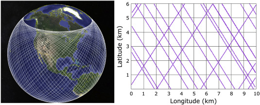

**Figura 1:** Distribució espacial GEDI [Font](https://doi.org/10.1016/j.srs.2020.100002)

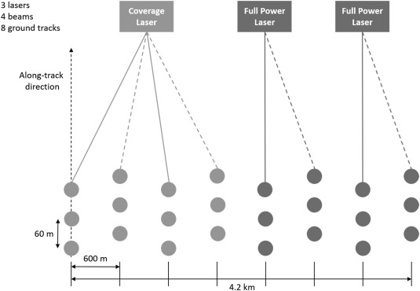

**Figura 2:** Distribució sensors [Font](https://doi.org/10.1016/j.srs.2020.100002)

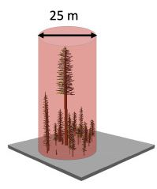

**Figura 3:** Footprint GEDI [Font](https://doi.org/10.1016/j.srs.2020.100002)

Aquestes dades s’utilitzaran per a derivar una varietat d’empremtes i productes en graella, incloent-hi l’alçada de la copa, els perfils de copa, l’Índex d’Àrea foliar (LAI), el sotabosc i la biomassa.

A continuació s’adjunta una taula (*Taula 1*) amb tota la informació dels diferents productes GEDI. En el nostre cas, **ens centrarem en els porductes 2A i 2B** que ens proporcionen unes dades més enfocades als nostres tipus d’anàlisis.

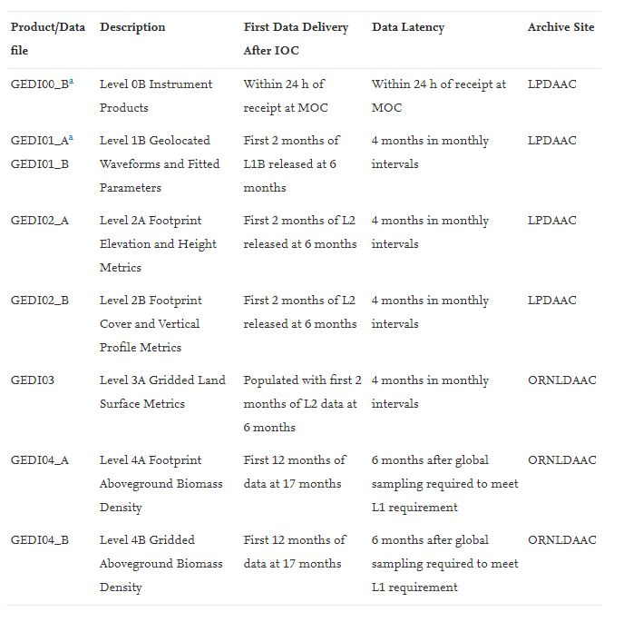

**Taula 1:** Productes GEDI [Font](https://doi.org/10.1016/j.srs.2020.100002)

**Level 2: Alçada de l’arbrat i mètriques de perfil vertical a nivell de footprint**

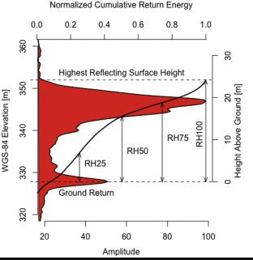

**Figura 4:** Exemple GEDI level 2A [Font](https://doi.org/10.1016/j.srs.2020.100002)

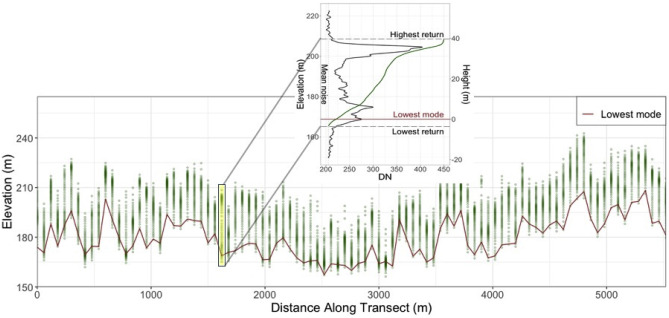

**Figura 5:** Exemple level 2B [Font](https://doi.org/10.1016/j.srs.2020.100002)

**Per saber-ne més:**

- Paper de missió: https://doi.org/10.1016/j.srs.2020.100002
- Plana web del projecte: https://gedi.umd.edu/
- Paquet d’R per tractar les dades: https://github.com/carlos-alberto-silva/rGEDI
- Vídeo explicatiu: https://www.youtube.com/watch?v=Q-slSZnDnL8
- Informacio productes L2A i L2B
  - LEVEL 2A: https://lpdaac.usgs.gov/products/gedi02_av001/
  - LEVEL 2B: https://lpdaac.usgs.gov/products/gedi02_bv001/
  - GediFinder: https://lpdaacsvc.cr.usgs.gov/services/gedifinder
  - Portal de descàrrega: https://earthdata.nasa.gov/

```r
print("Hello word")
```

```
[1] "Hello word"
```